# Vegitation Density in the Greater Vancouver Area

What is the Relationship Between Income and Vegetation Density in the Greater Vancouver Area?

python

powerbi

Author

Skylar Carroll

Published

April 22, 2024

I used satellite data to analyze vegetation density and compared it to Stats Canada income data using Python and Power BI.

##### Download the [python notebook](https://github.com/SkyWes/ndvi-and-income)

### Key Questions

The urban heat island (UHI) effect results in the warming of cities due to reduced vegetation, with neighborhoods lacking green space being most vulnerable to this effect. This analysis investigates:

1. **Which neighborhoods in Vancouver are the greenest?**
2. **What is the relationship between income and vegetation density in the Greater Vancouver Area?**

### Data Sources and Tools

To explore these questions, I used: - **Sentinel-2 satellite data** to analyze vegetation density. - **Statistics Canada census data** to examine income distribution. - **Python** for data processing and transformation. - **Power BI** for creating an interactive data visualization dashboard.

### Data Transformation Steps

#### 1. Importing and Merging Satellite Data

Two TIFF files covered the geographical area of interest. These were imported as shown below:

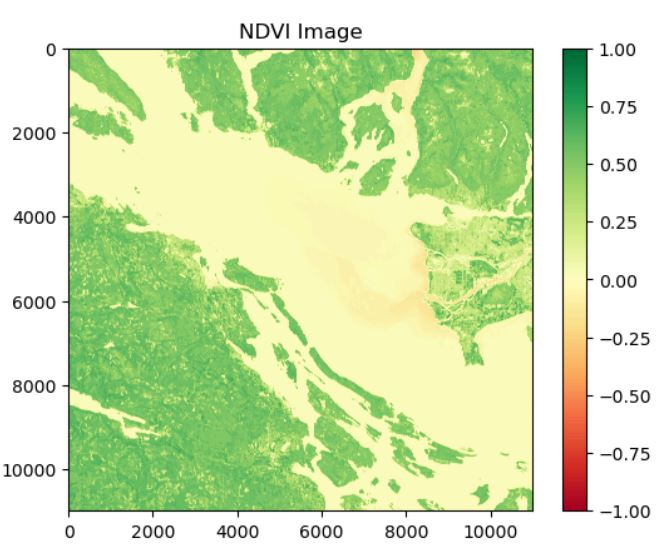

NDVI Image 1

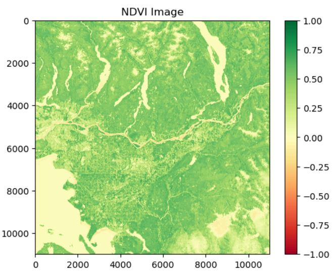

NDVI Image 2

Figure 1

After import, the two images were merged to form a single comprehensive NDVI image of the area.

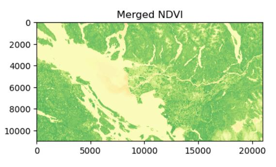

Merged NDVI

#### 2. Masking Water Areas

To calculate accurate vegetation density statistics, I created a mask to exclude water data:

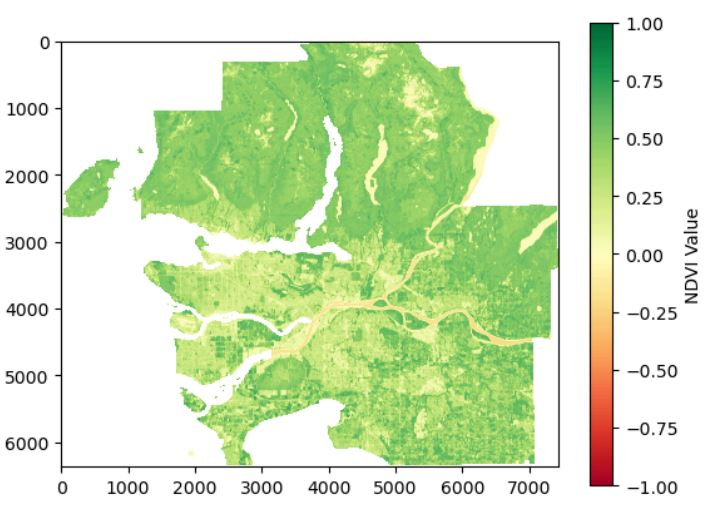

Masked NDVI

#### 3. Calculating and Visualizing NDVI

The **Normalized Difference Vegetation Index (NDVI)**, a measure of vegetation health, was computed for the area. A histogram was plotted to visualize the distribution of NDVI values:

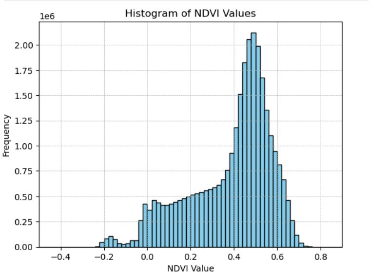

NDVI Distribution

#### 4. Income Data Transformation

After importing and cleaning income data from Statistics Canada, I visualized the distribution of average income for the Greater Vancouver Area:

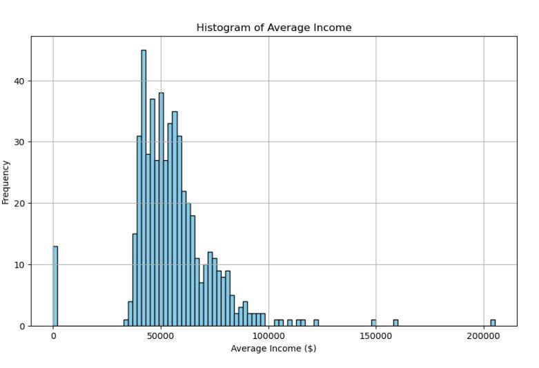

Average Income Distribution

#### 5. Building the Interactive Dashboard

The cleaned datasets were imported into Power BI, where I built a semantic model and designed an interactive dashboard. Explore the dashboard here:

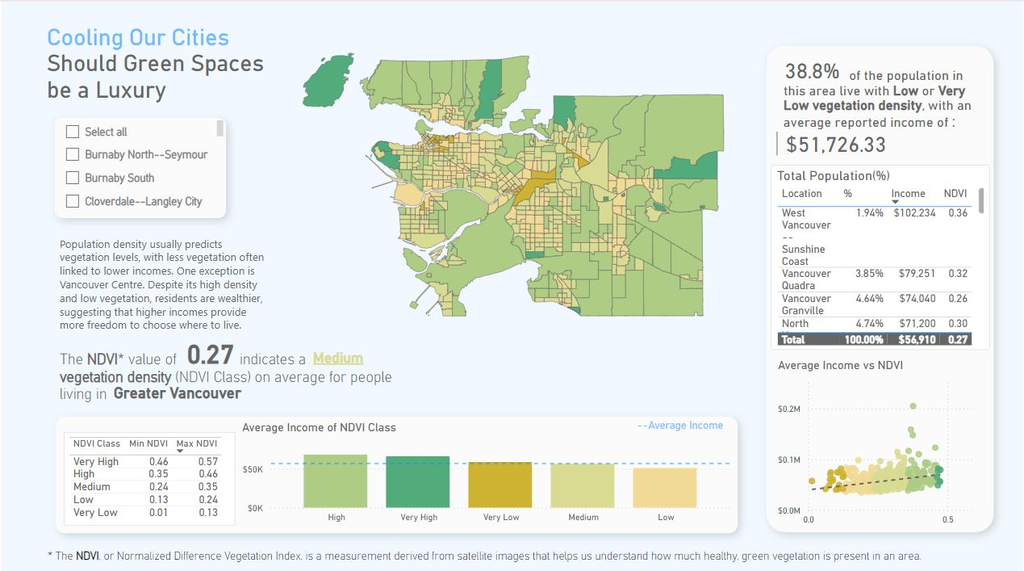

Click img to use Dashboard

### Key Findings

- **Income and Vegetation Density**: There is a weak positive correlation between income and vegetation density, likely influenced by higher-income individuals having the flexibility to acquire properties with more green space.
- **Notable Neighborhoods**:
  - **Olympic Village**: A high-income area with lower NDVI values, indicating less greenery.
  - **University of British Columbia (UBC)**: Despite its relatively lower income (likely due to a large student population), UBC has high NDVI values, showcasing significant greenery.

These findings highlight potential areas for targeted urban greening initiatives to mitigate the urban heat island effect and promote environmental equity.